# Applying K-Means Clustering in retail industry

Author

Charan Gullipalli, Lavanya Guntupalli, Arun Pandian (Advisor: Dr. Cohen)

Published

December 9, 2025

Slides: Presentation

# 1 Introduction

In today’s data-driven corporate world, knowing customer behavior and properly controlling inventory are crucial for organizational success. Data mining and clustering techniques, such as K-Means clustering, are crucial decision-making tools in retail, logistics, and marketing due to increasing access to transactional, demographic, and behavioral data. Recent studies show that algorithm selection and data pretreatment have a direct impact on the quality of clustering insights (Prasetiya and Prayoga (2025)).

K-Means has helped small enterprises with minimal resources in emerging countries. Clustering transactional and demographic data helps grocery shops detect patterns in consumer shopping behavior (Sitorus et al. (2023)). Research indicates that clustering can improve targeted marketing, loyalty programs, and stock management (Bala (2012)). These studies show that K-Means-based segmentation can help small merchants coordinate supply, demand, and promotional strategies.

Clustering methods, such as weighted variants (Omol et al. (2024)) and Global and MiniBatch K-Means, have increased computing efficiency and accuracy, addressing concerns like random initialization and scalability on big datasets. Many research lack clear preprocessing choices, fail to evaluate cluster quality, or use proprietary datasets that are difficult to replicate.

This study uses K-Means clustering to resolve gaps in an open government retail dataset and includes comprehensive documentation.

- Steps for data cleaning and feature engineering
- Determine the ideal number of clusters based on statistical and managerial criteria.
- Validate the clusters using internal evaluation indices.

K-Means clustering is more than just a statistical technique; it’s a strategic tool for data-driven decisions. Identifying behavioral patterns in huge datasets can help organizations improve customer understanding, optimize resource allocation, and estimate demand more precisely. Integrating K-Means into corporate analytics frameworks is vital for operational excellence and competitiveness in the digital age.

## 1.1 Literature Review

K-Means clustering is commonly used in retail to enhance consumer segmentation and inventory forecasting. From 2019-2024, Prasetiya and Prayoga (2025) found that integrating K-Means with association rule learning, such as FP-Growth, can help merchants better analyze customer behavior and generate targeted marketing strategies. The review demonstrates that K-Means is reliable on big datasets and may be used to classify products based on sales speed, including fast-moving and slow-moving commodities.

Bala (2012) proposed a forecasting approach that combines clustering and demand prediction. This technique enhanced inventory accuracy, decreased extra stock, and minimized shortages, demonstrating how clustering can enhance supply chain efficiency. Sitorus et al. (2023) used K-Means to categorize products by demand at a retail store, resulting in three categories: fast, moderate, and slow sellers. This helped to optimize stock levels and lower costs.

These studies show that K-Means clustering can improve retailers’ marketing precision and inventory control by discovering client trends and correlating them to product demand. Clustering results can help match promotional campaigns with inventory decisions, resulting in a data-driven retail management system (Prasetiya and Prayoga (2025); Omol et al. (2024); Bala (2012); Sitorus et al. (2023)).

# 2 Methods

K-Means is an unsupervised machine learning algorithm that groups related data points into distinct clusters. The algorithm divides data into K groups based on value similarity. Each group has a centroid, where all items are located in the center.

The K-Means approach separates a set of observations (x1,x2,…,xn) into K distinct clusters (C1,C2,…,CK) by minimizing the Within-Cluster Sum of Squares (WCSS):

$$WCSS = \sum_{k=1}^{K} \sum_{x_i \in C_k} \| x_i - \mu_k \|^2$$

where uk is the centroid (mean vector) of cluster Ck and ||.|| denotes the Euclidean norm.

The goal is to create clusters that are both compact (low variance inside) and distinct (big separation between centers).

This project use the K-Means method to categorize items or suppliers based on their performance and sales behavior. The primary goal is to identify patterns, such as which things sell quickly, moderately, or slowly. Creating clusters helps us identify sales trends and make better inventory and management decisions.

This helps with:

- Determine whether things move quickly, moderately, or slowly.
- Analyze sales trends and supplier performance.
- Improve decision-making for planning and replenishing.
- Break down enormous amounts of data into relevant, understandable groups.

In simple terms: This project uses K-Means clustering to automatically categorize commodities or suppliers based on their behavior. Transforming complex data into clear insights enhances understanding of trends, decision-making, and inventory management.

## 2.1 Determining the Optimal Number of Clusters

Choosing an appropriate number of clusters (𝐾) is critical for effective segmentation. Three complimentary approaches were utilized:

1. **Elbow Method**: The Within-Cluster Sum of Squares (WCSS) was compared to increasing values of 𝐾. The optimal value is indicated by a dramatic fall in the pace of improvement (“the elbow”). (MacQueen (1967))

$$WCSS = \sum_{k=1}^{K} \sum_{x_i \in C_k} \| x_i - \mu_k \|^2$$

2. **Silhouette Coefficient**: This metric assesses how well each observation fits in its allocated cluster compared to nearby clusters, with values ranging from -1 (poor) to +1 (well-separated). (Rousseeuw (1987))

$$s(i) = \frac{b(i) - a(i)}{\max(a(i), b(i))}$$

- Fast moving items,
- Moderately moving items,
- Slow-moving items

The ideal number of clusters for this investigation was determined to be 𝐾 = 3.

## 2.2 K-Means Clustering Process

After selecting =3, the K-Means technique was used to analyze the standardized feature space (TOTAL_SALES, RETAIL SALES, WAREHOUSE SALES).

The main algorithmic steps (Lloyd (1982)) are:

1.**Initialization:**

- Randomly set 𝐾 = 3 centroids in the feature space, or
- Use K-Means initialization for better beginning positions.

2.**Assignment step:** For each item (x_i), compute the Euclidean distance to each centroid (u_k):

$$d(x_i, \mu_k) = \| x_i - \mu_k \|_2$$

Assign (x_i) to the cluster with the closest centroid.

3.**Update step:** -For each cluster Ck, recompute the centroid as the mean of its members:

$$\mu_k = \frac{1}{|C_k|} \sum_{x_i \in C_k} x_i$$

4.**Convergence:**

- Repeat the assignment and update stages until the centroids stabilize (changes below a specified threshold) or the maximum number of iterations is reached. Our investigations showed that convergence often happened after a few repetitions.

## 2.3 Cluster Validation and Profiling

Clusters were classified as Fast, Moderate, or Slow-Moving based on their profiles.

# 3 Analysis and Results

## 3.1 Data Exploration and Visualization

**Data Sources and Collection:**

The Montgomery County Maryland Open Data Portal (Montgomery County, Maryland, Government (2025)) provided the dataset for this investigation.

The Department of Liquor Control collected complete monthly statistics on alcohol sales from 2017 to 2020 from retail and warehouse locations. Each record includes information regarding:

- Supplier name (vendor providing the product)
- item kind (beer, wine, spirits, etc.) and item code
- Retail sales, retail transfers, and warehouse sales are a few such sales channels.
- Temporal features: month and year

The dataset is constantly updated and released under a Public Domain License, promoting transparency in local government processes and facilitating replicable business analytics research.

## 3.2 Exploratory Analysis

Before using K-Means, the dataset was cleaned and summarized to analyze sales trends, supplier performance, and product movement. Using RStudio and tools like tidyverse, ggplot2, and lubridate, we created descriptive statistics and exploratory visualizations.

An example of cleansed data, aggregated at the item level, includes variables such as:

- YEAR, MONTH
- SUPPLIER, ITEM CODE, ITEM DESCRIPTION, ITEM TYPE
- RETAIL SALES, RETAIL TRANSFERS, WAREHOUSE SALES
- TOTAL_SALES

```r
# loading packages
library(tidyverse)
library(knitr)
library(ggthemes)
library(ggrepel)
library(dslabs)


# Load libraries
library(readxl)
library(dplyr)
library(ggplot2)
library(lubridate)
library(scales)



data <- read_excel("Retail_Sales.xlsx")







# Remove duplicate rows
data <- distinct(data)

# Handle missing values (replace or remove)
data <- data %>%
  mutate(
    SUPPLIER = ifelse(is.na(SUPPLIER), "Unknown Supplier", SUPPLIER),
    `ITEM TYPE` = ifelse(is.na(`ITEM TYPE`), "Unknown Type", `ITEM TYPE`),
    `RETAIL SALES` = ifelse(is.na(`RETAIL SALES`), 0, `RETAIL SALES`),
    `RETAIL TRANSFERS` = ifelse(is.na(`RETAIL TRANSFERS`), 0, `RETAIL TRANSFERS`),
    `WAREHOUSE SALES` = ifelse(is.na(`WAREHOUSE SALES`), 0, `WAREHOUSE SALES`)
  )

# Create a Total Sales column
data <- data %>%
  mutate(TOTAL_SALES = `RETAIL SALES` + `RETAIL TRANSFERS` + `WAREHOUSE SALES`)

# Combine YEAR and MONTH into a proper Date column
data <- data %>%
  mutate(Date = make_date(YEAR, MONTH, 1))
```

**Total Sales Trend Over Time**

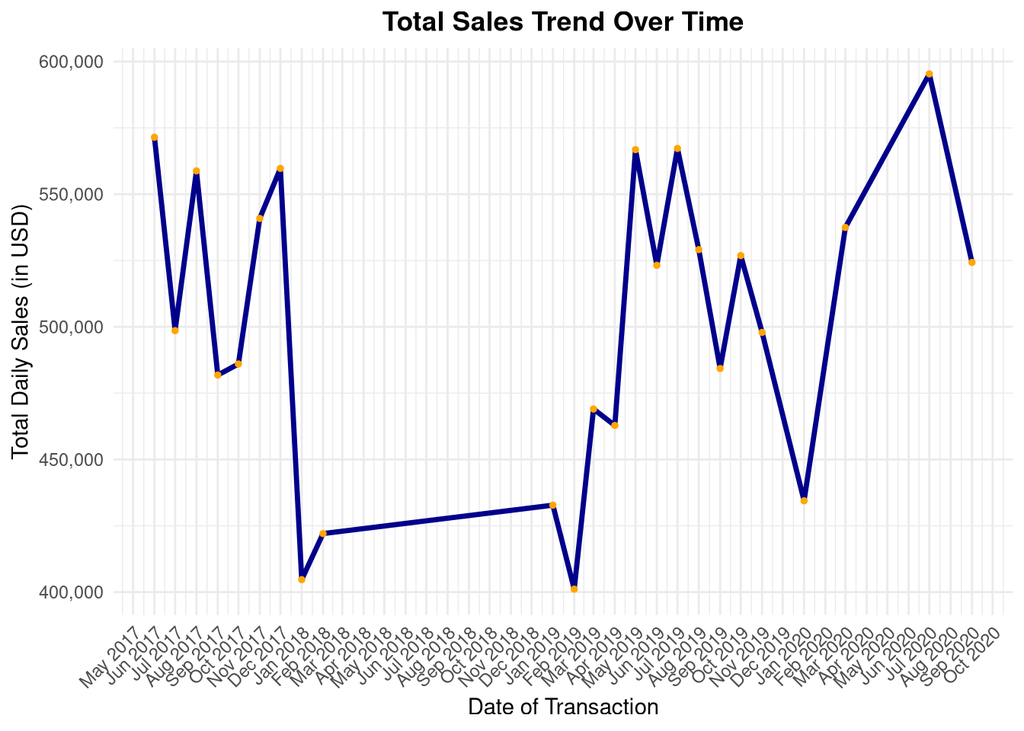

```r
# Total Sales Trend Over Time

library(ggplot2)
library(dplyr)
library(lubridate)
library(scales)

# Ensure the Date column is in date format
data <- data %>%
  mutate(Date = as.Date(Date))

# Aggregate sales by date (if multiple transactions per day)
daily_sales <- data %>%
  group_by(Date) %>%
  summarise(Total_Sales = sum(TOTAL_SALES, na.rm = TRUE))

# Line chart for total sales trend
ggplot(daily_sales, aes(x = Date, y = Total_Sales)) +
  geom_line(color = "darkblue", size = 1.2) +
  geom_point(color = "orange", size = 1) +
  labs(
    title = "Total Sales Trend Over Time",
    x = "Date of Transaction",
    y = "Total Daily Sales (in USD)"
  ) +
  scale_x_date(date_labels = "%b %Y", date_breaks = "1 month") +
  scale_y_continuous(labels = comma) +
  theme_minimal() +
  theme(
    axis.text.x = element_text(angle = 45, hjust = 1),
    plot.title = element_text(face = "bold", hjust = 0.5)
  )
```

**Top 10 Suppliers by Total Sales**

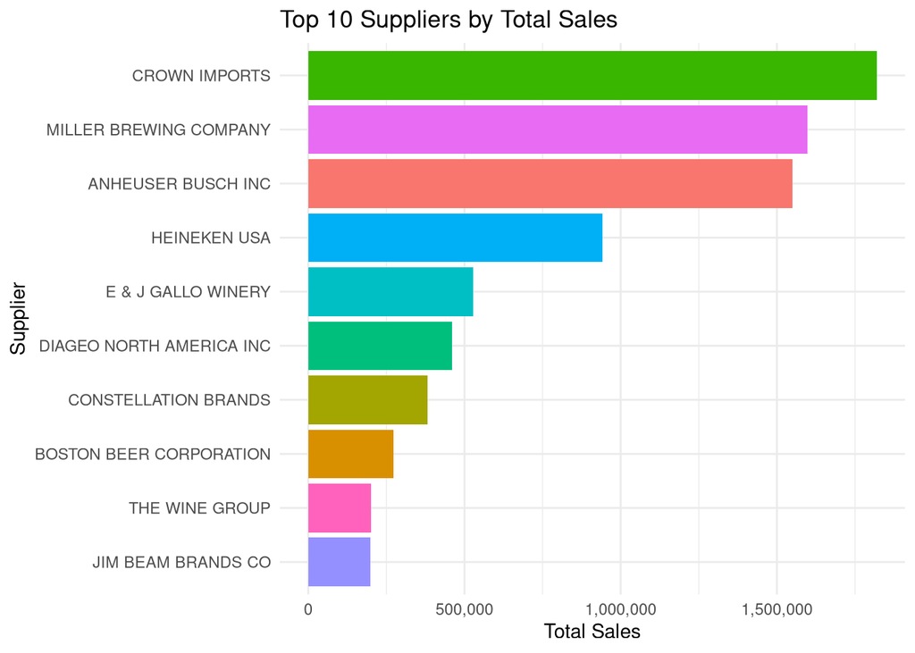

```r
# Top 10 Suppliers by Total Sales

top_suppliers <- data %>%
  group_by(SUPPLIER) %>%
  summarise(Total_Sales = sum(TOTAL_SALES, na.rm = TRUE)) %>%
  arrange(desc(Total_Sales)) %>%
  head(10)

ggplot(top_suppliers, aes(x = reorder(SUPPLIER, Total_Sales), y = Total_Sales, fill = SUPPLIER)) +
  geom_bar(stat = "identity") +
  coord_flip() +
  labs(title = "Top 10 Suppliers by Total Sales", x = "Supplier", y = "Total Sales") +
  scale_y_continuous(labels = comma) +
  theme_minimal() +
  theme(legend.position = "none")
```

**Insights:**Sales analysis shows that a small number of suppliers account for the majority of total income. Crown Imports, Miller Brewing Company, and Anheuser Busch Inc. have the highest sales, indicating a concentrated supply base where major vendors own the majority of the market. Maintaining strong supplier connections and accurate demand forecasting is crucial for these significant contributors.

**Sales by Item Type**

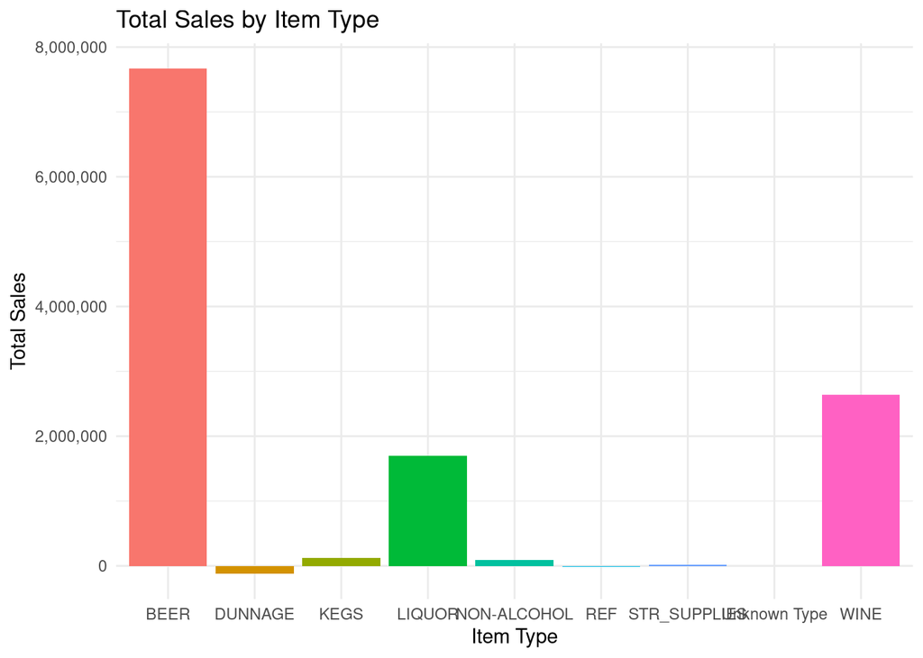

```r
# Sales by Item Type

ggplot(data, aes(x = `ITEM TYPE`, y = TOTAL_SALES, fill = `ITEM TYPE`)) +
  geom_bar(stat = "summary", fun = "sum") +
  labs(title = "Total Sales by Item Type", x = "Item Type", y = "Total Sales") +
  scale_y_continuous(labels = comma) +
  theme_minimal() +
  theme(legend.position = "none")
```

- Beer’s dominance indicates a fast-moving inventory sector due to regular use and strong brand loyalty. Goods classified as “Kegs” and “Non-Alcoholic” move slowly and require targeted marketing to increase sales.

**Comparison: Retail vs Warehouse Sales**

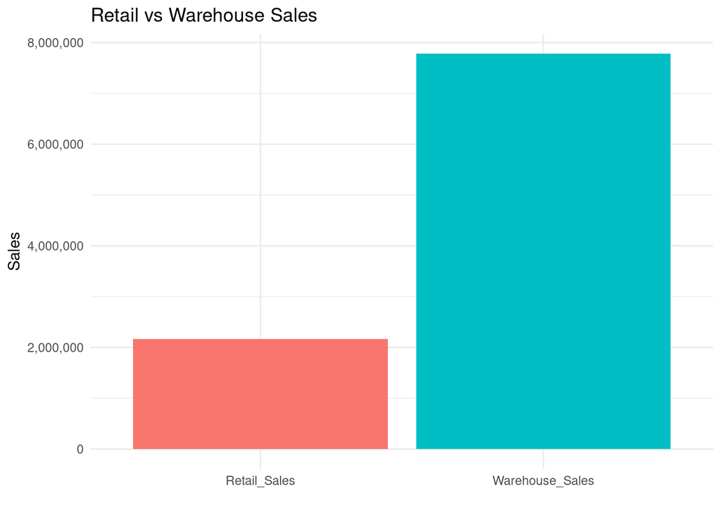

```r
# Comparison: Retail vs Warehouse Sales

sales_compare <- data %>%
  summarise(
    Retail_Sales = sum(`RETAIL SALES`, na.rm = TRUE),
    Warehouse_Sales = sum(`WAREHOUSE SALES`, na.rm = TRUE)
  ) %>%
  tidyr::pivot_longer(cols = everything(), names_to = "Category", values_to = "Sales")

ggplot(sales_compare, aes(x = Category, y = Sales, fill = Category)) +
  geom_bar(stat = "identity") +
  labs(title = "Retail vs Warehouse Sales", x = "", y = "Sales") +
  scale_y_continuous(labels = comma) +
  theme_minimal() +
  theme(legend.position = "none")
```

**Monthly Sales Heatmap**

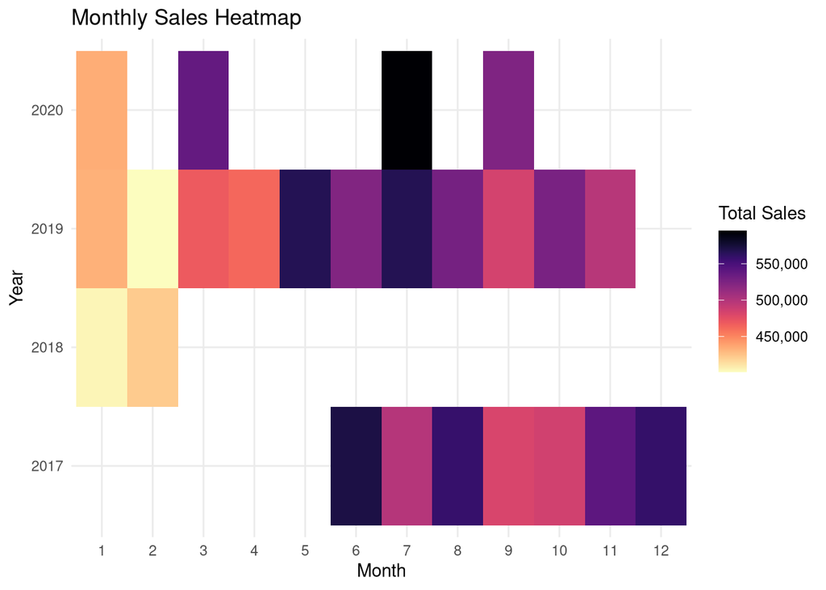

```r
# Monthly Sales Heatmap
library(viridis)

monthly_sales <- data %>%
  group_by(YEAR, MONTH) %>%
  summarise(Total_Sales = sum(TOTAL_SALES, na.rm = TRUE))

ggplot(monthly_sales, aes(x = factor(MONTH), y = factor(YEAR), fill = Total_Sales)) +
  geom_tile() +
  scale_fill_viridis(option = "magma", direction = -1, labels = comma) +
  labs(title = "Monthly Sales Heatmap", x = "Month", y = "Year", fill = "Total Sales") +
  theme_minimal()
```

**Insights:**Sales activity often peaks between December and the middle of the year, driven by seasonal and holiday demand. Early months show reduced sales, while anomalies in 2020 indicate potential external interruptions such the COVID-19 pandemic. Identifying seasonal changes helps plan stock levels more effectively.

## 3.3 Visualization-Based Evidence

These visual patterns complement the mathematical cluster profiles and support the classification of Clusters 1, 2, and 3 as fast, slow, and moderate moving groups.

# 4 Modeling and Results

## 4.1 Modeling and Data Preparation

To develop the K-Means model, the dataset was prepared to ensure accurate and consistent item representation. Duplicate records were deleted, missing values were addressed, and sales from three channels (retail, warehouse, and retail transfers) were integrated into a single TOTAL_SALES metric to accurately reflect item performance. These cleansed and condensed variables laid the groundwork for clustering.

## 4.2 Data Preprocessing

The Montgomery County retail dataset included monthly sales records for all suppliers, items, and sales channels. To prepare the data for K-Means, multiple preprocessing processes were performed:

- **Aggregation**: Monthly records were combined into one row per supplier-item combination, including Retail Sales, Retail Transfers, and Warehouse Sales.
- **Feature Creation**: A new variable, TOTAL_SALES, was created to reflect all sales activity.
- **Missing Values**: Missing numeric sales values were substituted with zeros when applicable.
- **Reduplication**: Duplicate entries have been removed to prevent excess specific items.
- **Filtering**: Items with no sales activity were removed from modeling.
- **Standardization**: Clustering variables (TOTAL_SALES, RETAIL_SALES, and WAREHOUSE_SALES) were normalized to prevent scale gaps from affecting distance calculations.

The preparation methods ensured a clean, consolidated dataset suited for cluster creation.

```r
library(tidyverse)
library(readxl)
library(lubridate)
library(cluster)    # for silhouette()
library(factoextra) # for convenient plots (optional)
library(scales)

# Read Excel file
retail_raw <- read_excel("Retail_Sales.xlsx")

# Aggregate to item level: one row per supplier-item
items <- retail_raw %>%
  group_by(SUPPLIER, `ITEM CODE`, `ITEM DESCRIPTION`, `ITEM TYPE`) %>%
  summarise(
    RETAIL_SALES     = sum(`RETAIL SALES`, na.rm = TRUE),
    RETAIL_TRANSFERS = sum(`RETAIL TRANSFERS`, na.rm = TRUE),
    WAREHOUSE_SALES  = sum(`WAREHOUSE SALES`, na.rm = TRUE),
    .groups = "drop"
  ) %>%
  mutate(
    TOTAL_SALES = RETAIL_SALES + RETAIL_TRANSFERS + WAREHOUSE_SALES
  ) %>%
  filter(TOTAL_SALES > 0)  # keep only items that actually sold something

# Numeric features for clustering
features <- items %>%
  select(TOTAL_SALES, RETAIL_SALES, WAREHOUSE_SALES)

# Scale features
features_scaled <- scale(features)
```

## 4.3 Elbow Method Code

The Elbow Method was used to calculate the Within-Cluster Sum of Squares (WCSS) for 𝐾 values ranging from 2 to 8. The Elbow plot illustrates how WCSS reduces with more clusters. A sharp drop followed by a flattening of the curve, known as a “elbow,” shows a strong balance of simplicity and precision.

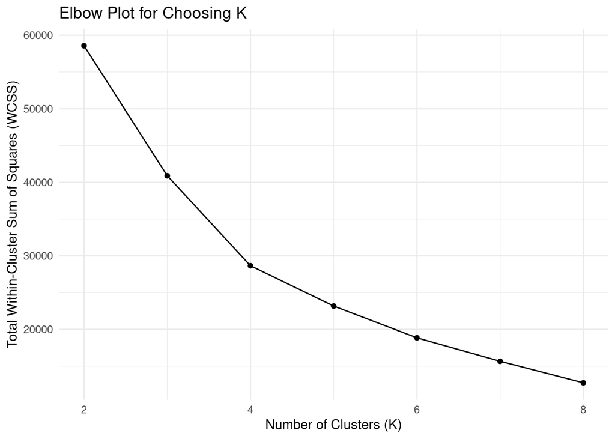

```r
set.seed(123)

k_values <- 2:8

wcss <- map_dbl(k_values, function(k) {
  kmeans(features_scaled, centers = k, nstart = 10)$tot.withinss
})

elbow_df <- tibble(
  k = k_values,
  WCSS = wcss
)

ggplot(elbow_df, aes(x = k, y = WCSS)) +
  geom_line() +
  geom_point() +
  labs(
    title = "Elbow Plot for Choosing K",
    x = "Number of Clusters (K)",
    y = "Total Within-Cluster Sum of Squares (WCSS)"
  ) +
  theme_minimal()
```

Using WCSS patterns, 𝐾=3 creates a meaningful structure with minimal unneeded complexity.

## 4.4 Silhouette Method

To validate the Elbow Method, a Silhouette analysis was performed for 𝐾 = 3. The Silhouette score assesses how closely each item aligns with its own cluster compared to others. Clusters with values near +1 show strong cohesiveness and distinct separation.

```r
set.seed(123)

# Fit K-Means with K = 3
k <- 3
k3_model <- kmeans(features_scaled, centers = k, nstart = 25)

# Silhouette object
sil_obj <- silhouette(k3_model$cluster, dist(features_scaled))

# Average silhouette width (you can quote this number in your text)
mean_silhouette <- mean(sil_obj[, "sil_width"])
mean_silhouette
```

```
[1] 0.9712268
```

```
  cluster  size ave.sil.width
1       1    17          0.19
2       2 37667          0.98
3       3   240          0.09
```

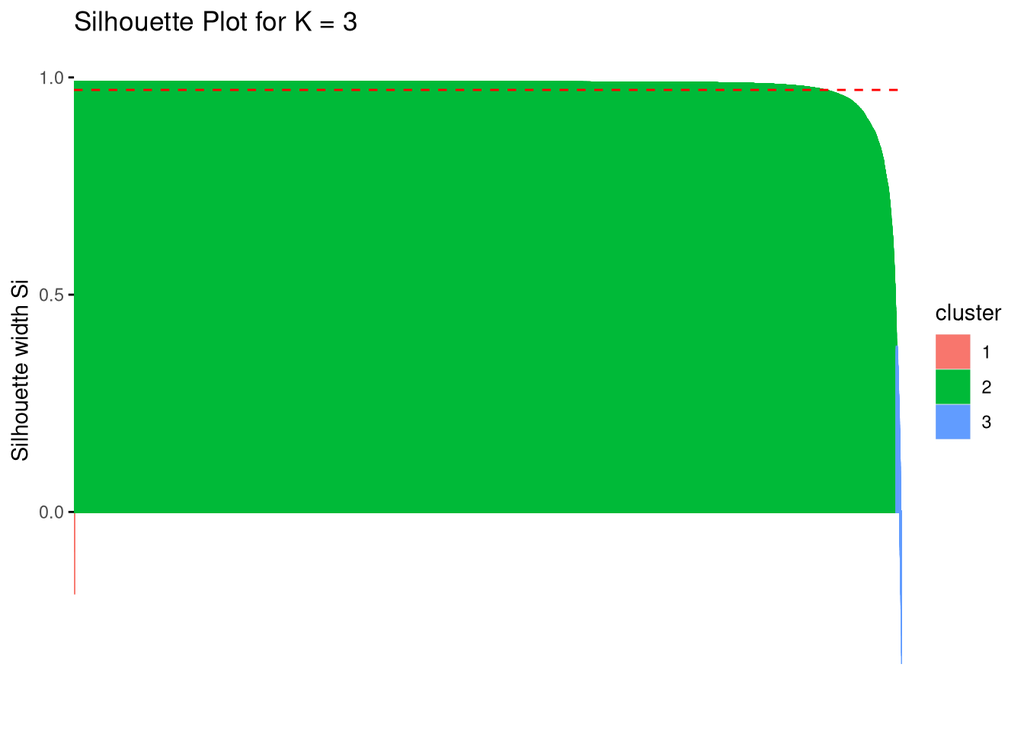

```r
# Plot silhouette for K = 3
fviz_silhouette(sil_obj) +
  labs(title = "Silhouette Plot for K = 3")
```

The average Silhouette score was 0.97, indicating outstanding clustering performance. Cluster 2 had a Silhouette width of 0.98, indicating tight grouping and significant separation, perhaps due to its high number of low-sales goods. Clusters 1 and 3 had lower Silhouette values (0.19 and 0.09), consistent with smaller high-value and mid-value groups located further away from the main slow-moving cluster.

The high overall Silhouette score indicates that 𝐾=3 creates well-defined and meaningful clusters.

## 4.5 Cluster Profiling(Sizes + Centroids + Summary)

After clustering, the features of each cluster were analyzed using their sizes, centroid values (scaled units), and summary statistics (original units). This profiling stage translates numerical cluster assignments into relevant business categories.

```r
# Add cluster labels back to item data
items_clustered <- items %>%
  mutate(cluster = factor(k3_model$cluster))
```

```r
# Cluster sizes (how many items in each cluster)
cluster_sizes <- items_clustered %>%
  count(cluster)

cluster_sizes
```

| cluster | n |
| --- | --- |
| 1 | 17 |
| 2 | 37667 |
| 3 | 240 |

The cluster size results showed a very uneven distribution:

- Cluster 1: 17 items
- Cluster 2: 37,667 items
- Cluster 3: 240 items

```r
# Centroids on scaled features (for technical report)
cluster_centroids_scaled <- as_tibble(k3_model$centers) %>%
  mutate(cluster = factor(1:3))

cluster_centroids_scaled
```

| TOTAL_SALES | RETAIL_SALES | WAREHOUSE_SALES | cluster |
| --- | --- | --- | --- |
| 36.5600884 | 24.2722508 | 36.2372995 | 1 |
| -0.0440051 | -0.0527063 | -0.0381325 | 2 |
| 4.3167469 | 6.5527496 | 3.4179283 | 3 |

```r
# Summary stats in original units (mean and median)
cluster_summary <- items_clustered %>%
  group_by(cluster) %>%
  summarise(
    mean_total_sales   = mean(TOTAL_SALES, na.rm = TRUE),
    median_total_sales = median(TOTAL_SALES, na.rm = TRUE),
    mean_retail_sales  = mean(RETAIL_SALES, na.rm = TRUE),
    mean_wh_sales      = mean(WAREHOUSE_SALES, na.rm = TRUE),
    .groups = "drop"
  )

cluster_summary
```

| cluster | mean_total_sales | median_total_sales | mean_retail_sales | mean_wh_sales |
| --- | --- | --- | --- | --- |
| 1 | 138991.321 | 110962.92 | 9532.07824 | 120142.56176 |
| 2 | 155.283 | 8.98 | 36.40421 | 82.73404 |
| 3 | 16695.224 | 12116.18 | 2614.95988 | 11521.16596 |

The centroids and averages revealed that:

- Cluster 1 has the most overall sales (about 139,000 on average), making it the Fastest Moving cluster.
- Cluster 2 has low total sales (about 155), indicating slow moving products.
- Cluster 3 has moderate overall sales (about 16,695), making it the Moderate-Moving cluster.

This three-group structure aligns with common retail inventory movement patterns and managerial stock classification frameworks. K-Means accurately identified high-demand items from mid-level and slow-moving products, as confirmed by the profile.

## 4.6 Cluster Visualization: Scatter Plot

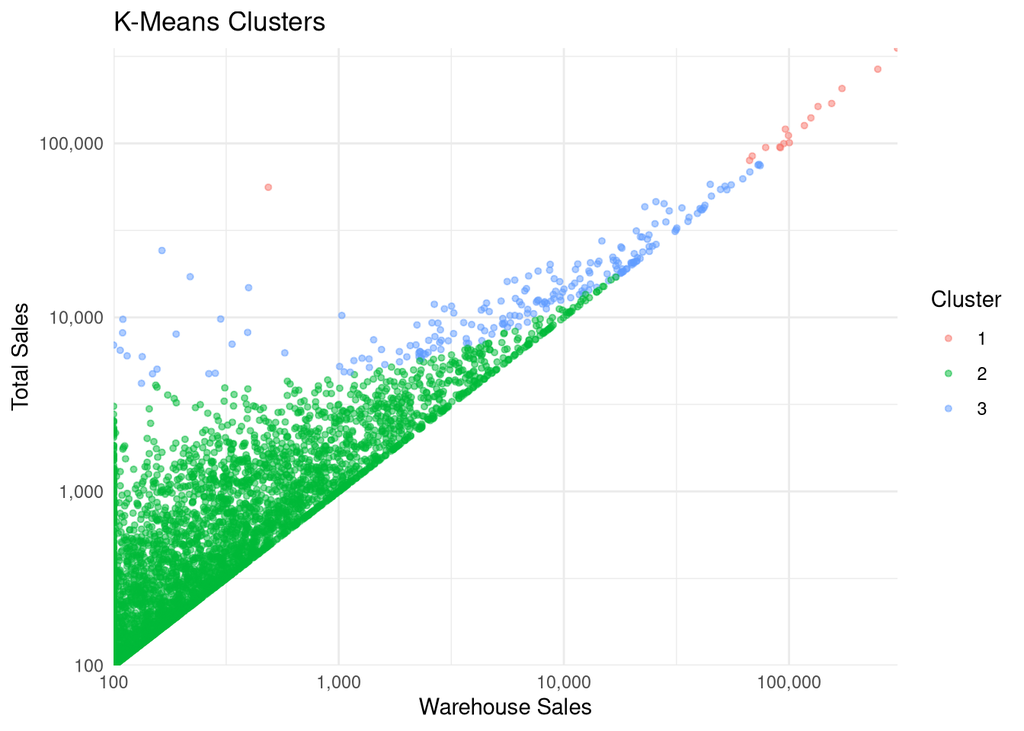

```r
ggplot(items_clustered,
       aes(x = WAREHOUSE_SALES,
           y = TOTAL_SALES,
           color = cluster)) +
  geom_point(alpha = 0.5, size = 1.1) +

  # X-axis: log10, start at 100, no gap
  scale_x_log10(
    labels = scales::comma,
    limits = c(100, NA),
    expand = c(0, 0)   # <-- removes the gap at the axis
  ) +

  # Y-axis: log10, start at 100, no gap
  scale_y_log10(
    labels = scales::comma,
    limits = c(100, NA),
    expand = c(0, 0)   # <-- removes the gap at the axis
  ) +

  labs(
    title = "K-Means Clusters",
    x = "Warehouse Sales",
    y = "Total Sales",
    color = "Cluster"
  ) +
  theme_minimal()
```

**Interpretation**

- Cluster 1: points in high-sales region → Fast-Moving.
- Cluster 2: dense cloud near origin → Slow-Moving.
- Cluster 3: middle zone → Moderate-Moving.

## 4.7 Cluster Formation and Categorization

Using K-Means with 𝐾=3, the dataset was separated into three clusters based on Total Sales, Retail Sales, and Warehouse Sales.

Using the cluster summary results:

- Cluster 1 has only 17 goods yet generates an average total sales of 138,991, including significant warehouse sales.
- Cluster 2 has 37,667 products, but has a low average total sales of 155, as well as low retail and warehouse sales.
- Cluster 3 comprises 240 items, with an average total sales of approximately 16,695, and intermediate warehouse and retail values.

This structure aligns with the conventional inventory classification of rapid, moderate, and slow-moving products, indicating that K-Means accurately reflects sales behavior.

## 4.8 Cluster Insights

**Slow-Moving Items (Cluster 2)** Slow-moving products comprise the largest cluster, although each sells in limited quantities. This category includes specialty, seasonal, or low-demand products, such as kegs and non-alcoholic beverages.

- They have a larger risk of overstocking and inventory holding costs.
- Managers can consider lowering order numbers, revising assortment, or offering promotions and discounts to move slow stock.
- Long-term slow movers may be discontinued if they do not align with strategic aims.

Overall, The three clusters provide a clear structure for the product portfolio. Managers might prioritize protecting the supply of fast-moving commodities, stabilizing moderate items, and reducing costs for slow-moving items.

# 5 Conclusion

## 5.1 Key Findings

- K-Means clustering classified products into three categories: Fast-Moving, Moderate-Moving, and Slow-Moving items.
- Beer and liquor brands from vendors like Crown Imports and Miller Brewing had high and consistent sales. These goods must be supplied often.
- Moderate-moving commodities, like wine, had average and consistent sales. They are stable products that require balanced inventories.
- Slow-moving items were typically niche or seasonal, with low or inconsistent sales. To prevent overstocking and storage expenses, these products must be carefully monitored.
- Sales increased during holiday seasons (e.g., summer and December), indicating that demand varies with time and events.

## 5.2 Results Summary

The clustering results helped group inventory based on sales behavior and stock movement.

This makes it easier for managers to:

- Focus on fast-selling items to keep shelves full,
- Maintain enough stock of moderate-selling items, and
- Reduce extra inventory of slow-selling items.

K-Means clustering improves inventory planning, reduces waste, and enables quick response to client demand. Overall, it improves inventory control, forecasting, and retail efficiency.

## 5.3 Limitations and Future Work

**Limitations**

**Cluster Size Imbalance:**One drawback is that Cluster 2 is significantly larger than Clusters 1 and 3. This reflects the fact that most retail items move slowly, but it also indicates that the clustering structure is severely uneven. This could affect how well the smaller high-value clusters are represented.

**K-Means Assumptions:**K-Means assumes spherical, uniformly sized clusters and is sensitive to initial centroid location and outliers. Given the skewed distribution of retail sales data, these assumptions may not always be valid.

**Limited Feature Set:**The analysis only considers sales-related factors (total sales, retail sales, and warehouse sales). Important business parameters, such as profit margin, price elasticity, promotional activity, consumer demographics, and item lifetime, were not considered and could have an impact on cluster formation.

**Future Work**

**Test Alternative Clustering Algorithms:**Investigate models that can handle skewed and imbalanced data, such as DBSCAN, Gaussian Mixture Models, and hierarchical clustering, to see if a more balanced segmentation emerges.

**Add more business features:**Use margin, profitability, seasonality indications, promotions, or RFM-style customer KPIs to create clusters that reflect both sales volume and business value.

**Try Weighted or Hybrid models:**Consider weighted K-Means, MiniBatch K-Means, or hybrid models to reduce sensitivity to extreme values and improve resilience.

**Extend to customer-level clustering:**Using the same dataset, cluster consumer behavior (frequency, recency, spend, brand loyalty) to supplement product-level segmentation.

## References

Bala, Pradip Kumar. 2012. “Improving Inventory Performance with Clustering-Based Demand Forecasts.” *Decision Tree-Based Demand Forecasts for Improving Inventory Performance*. https://www.researchgate.net/publication/261023207_Decision_tree_based_demand_forecasts_for_improving_inventory_performance.

Caliński, T., and J. Harabasz. 1974. “A Dendrite Method for Cluster Analysis.” *Communications in Statistics* 3 (1): 1–27. https://doi.org/10.1007/BF02291575.

Lloyd, S. 1982. “Least Squares Quantization in PCM.” *IEEE Transactions on Information Theory* 28 (2): 129–37. https://doi.org/10.1109/TIT.1982.1056489.

MacQueen, J. B. 1967. “Some Methods for Classification and Analysis of Multivariate Observations.” In *Proceedings of the Fifth Berkeley Symposium on Mathematical Statistics and Probability, Vol. 1*, 281–97. Berkeley, CA: University of California Press. https://projecteuclid.org/ebooks/berkeley-symposium-on-mathematical-statistics-and-probability/Proceedings-of-the-Fifth-Berkeley-Symposium-on-Mathematical-Statistics-and/chapter/Some-methods-for-classification-and-analysis-of-multivariate-observations/bsmsp/1200512992.

Montgomery County, Maryland, Government. 2025. “Warehouse and Retail Sales.” Montgomery County Data Portal; https://data.montgomerycountymd.gov/Community-Recreation/Warehouse-and-Retail-Sales/v76h-r7br/about_data.

Omol, Edwin, Dorcas Onyangor, Lucy Mburu, and Paul Abuonji. 2024. “Application of k-Means Clustering for Customer Segmentation in Grocery Stores in Kenya.” *International Journal of Science, Technology and Management (IJSTM)*. https://ijstm.inarah.co.id/index.php/ijstm/article/view/1024.

Prasetiya, Yanda Rizky, and Firlan Prayoga. 2025. “Systematic Literature Review: Customer Segmentation in Retail.” *Journal of Technovasia*. https://journal-iam.com/index.php/technovasia/article/view/11.

Rousseeuw, Peter J. 1987. “Silhouettes: A Graphical Aid to the Interpretation and Validation of Cluster Analysis.” *Journal of Computational and Applied Mathematics* 20: 53–65. https://doi.org/10.1016/0377-0427(87)90125-7.

Sitorus, Zulham, Irwan Syahputra, Chairul Indra Angkat, and Dewi Sartika. 2023. “Implementation of k-Means Clustering for Inventory Projection.” *International Journal of All Research in Science, Technology and Computers (IJARSCT)*. https://www.ijarsct.co.in/Paper19084.pdf.